# Volesti tutorial

Vissarion Fisikopoulos

16 October 2019

`volesti` is a `C++` package (with an `R` interface) for computing estimations of volume of polytopes given by a set of points or linear inequalities or Minkowski sum of segments (zonotopes). There are two algorithms for volume estimation and algorithms for sampling, rounding and rotating polytopes.

We can download the `R` package from https://CRAN.R-project.org/package=volesti

```r
# first load the volesti library
library(volesti)
packageVersion("volesti")
```

```
## [1] '1.0.3'
```

You have access to the documentation of volesti functions like volume computation and sampling.

```r
help("volume")
help("sample_points")
```

# Sampling

Sampling in the square.

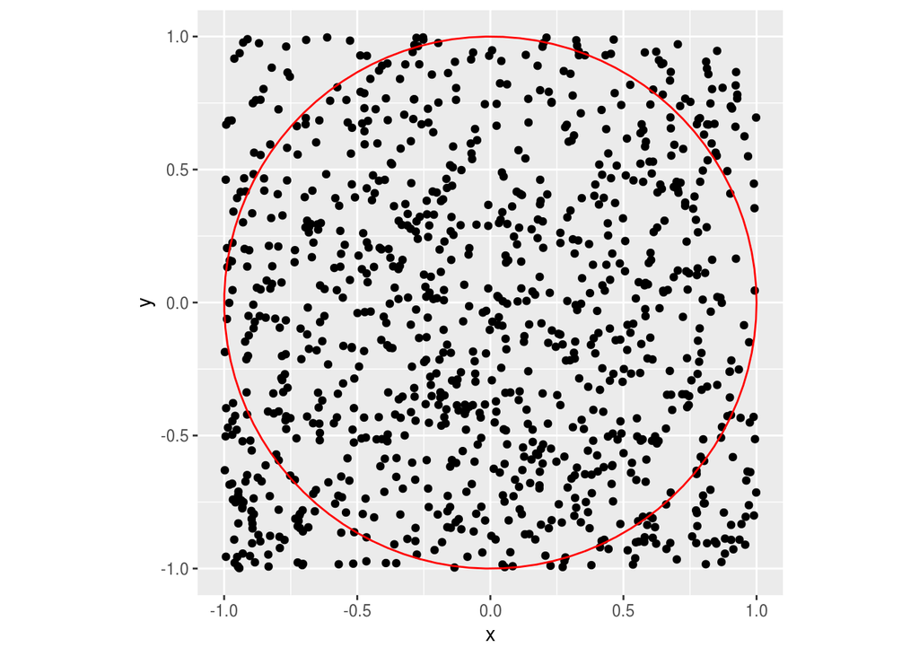

```r
library(ggplot2)
P = GenCube(2, 'H')
points1 = sample_points(P, WalkType = "RDHR", walk_step = 1, N=1000)
g<-ggplot(data.frame( x=points1[1,], y=points1[2,] )) + geom_point( aes(x=x, y=y))
g<-g+annotate("path",
   x=cos(seq(0,2*pi,length.out=100)),
   y=sin(seq(0,2*pi,length.out=100)),color="red")+coord_fixed()
plot(g)
```

Naive Monte Carlo fails in (not so) high dimensions.

```r
for (d in 2:20) {
  P = GenCube(d, 'H')

  num_of_points <- 100000
  count_inside <- 0
  tim1 = system.time({ points1 = sample_points(P, WalkType = "RDHR", walk_step = 1, N=num_of_points) })

  for (i in 1:num_of_points) {
    if (norm(points1[,i], type="2") < 1) {
      count_inside <- count_inside + 1
    }
  }
  vol_estimation <- count_inside*2^d/num_of_points
  vol_exact <- pi^(d/2)/gamma(d/2+1)

  cat(d, vol_estimation, vol_exact, (vol_estimation- vol_exact)/ vol_exact, "\n")
}
```

```
## 2 3.1396 3.141593 -0.0006342813
## 3 4.21296 4.18879 0.005770114
## 4 4.8904 4.934802 -0.008997767
## 5 5.28736 5.263789 0.00447795
## 6 5.39712 5.167713 0.04439241
## 7 4.5376 4.724766 -0.03961381
## 8 4.02432 4.058712 -0.008473655
## 9 3.1232 3.298509 -0.05314792
## 10 2.68288 2.550164 0.05204213
## 11 1.536 1.884104 -0.1847583
## 12 0.98304 1.335263 -0.2637854
## 13 1.55648 0.9106288 0.7092366
## 14 0.65536 0.5992645 0.09360719
## 15 0.98304 0.3814433 1.577159
## 16 0 0.2353306 -1
## 17 3.93216 0.1409811 26.8914
## 18 0 0.08214589 -1
## 19 0 0.0466216 -1
## 20 0 0.02580689 -1
```

## Sampling via random walks

`volesti` supports 3 types of random walks

1. Ball walk

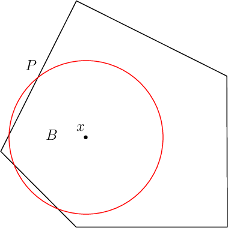

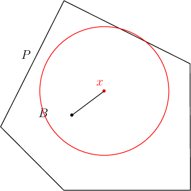

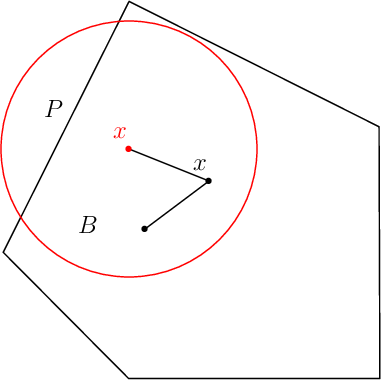

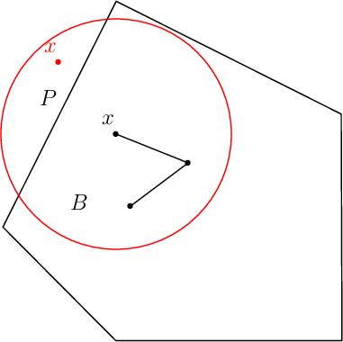

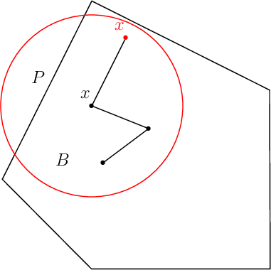

2. Random directions hit-and-run

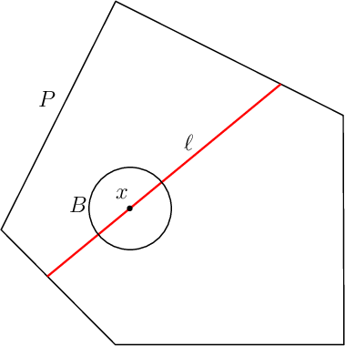

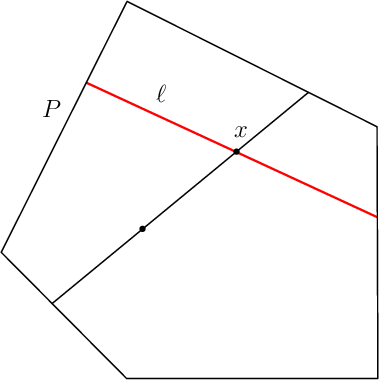

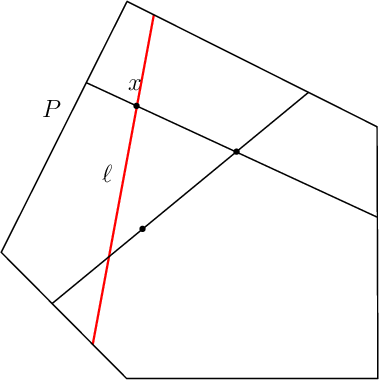

3. Coordinate directions hit-and-run

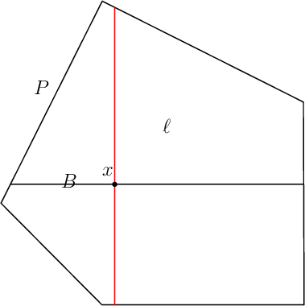

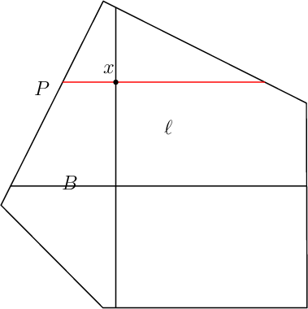

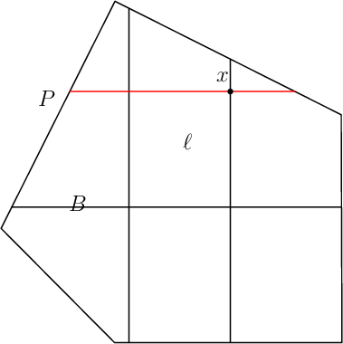

There are two important parameters `cost per step` and `mixing time` that affects the accuracy and performance of the walks. Below we illustrate this by choosing different walk steps for each walk while sampling on the 100-dimensional cube.

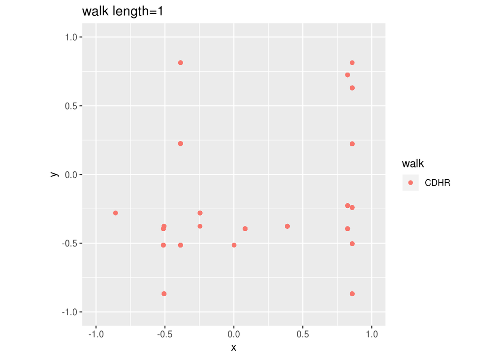

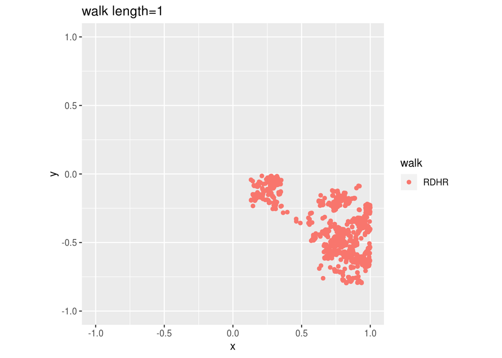

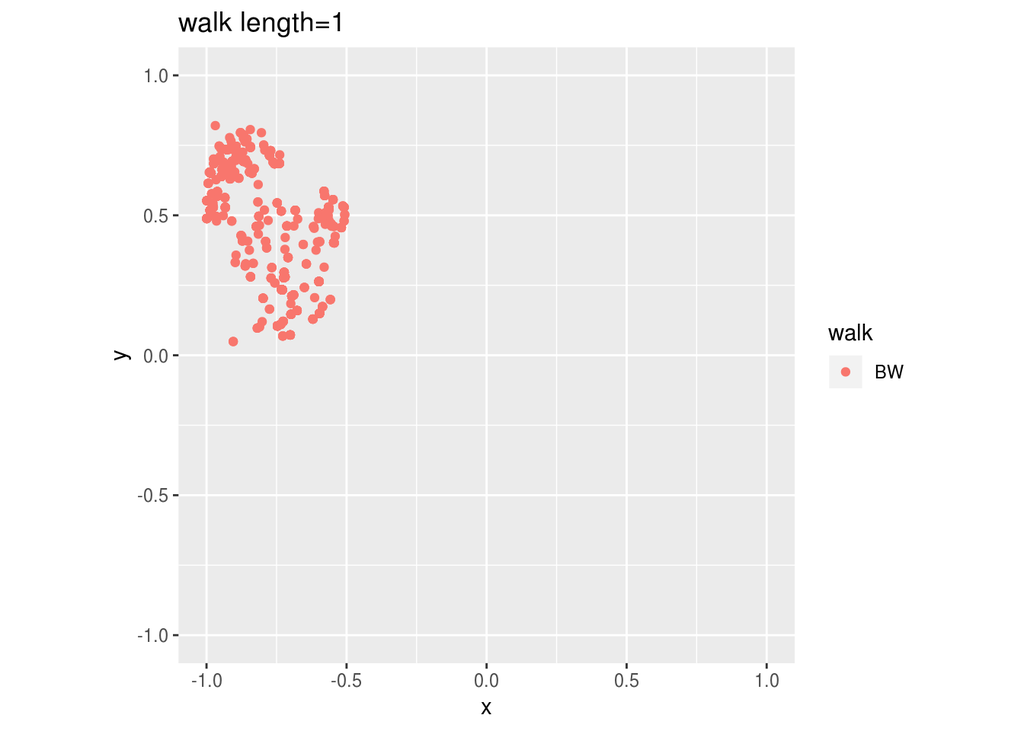

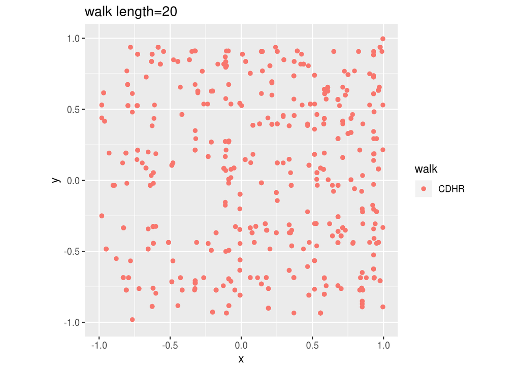

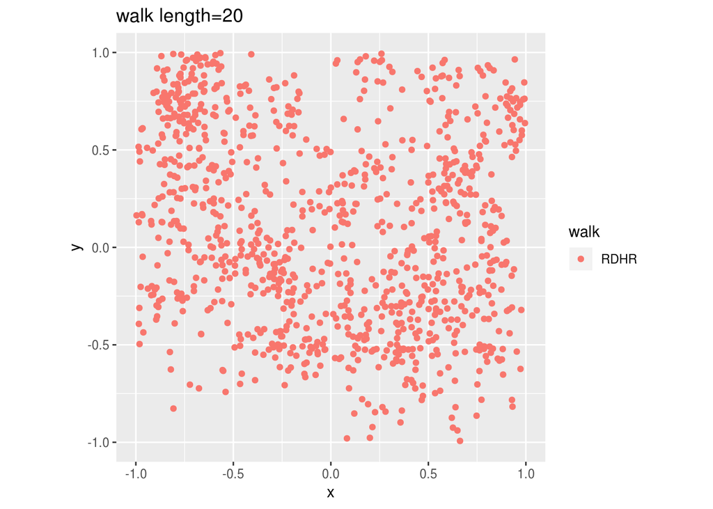

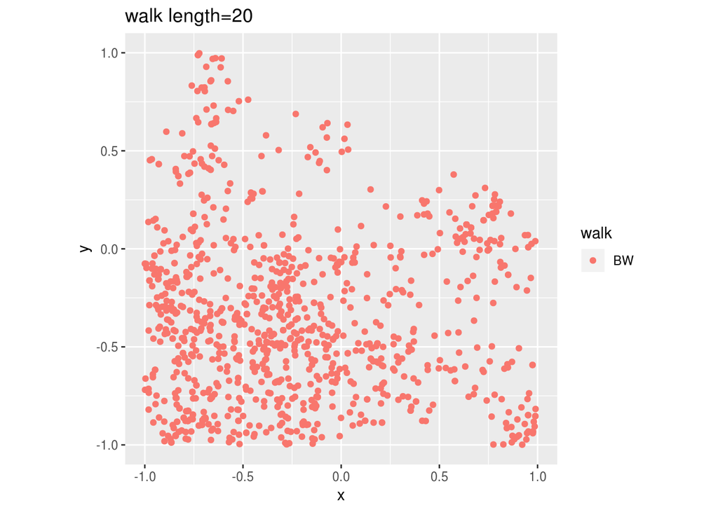

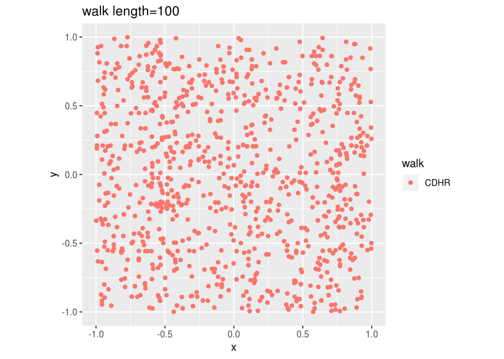

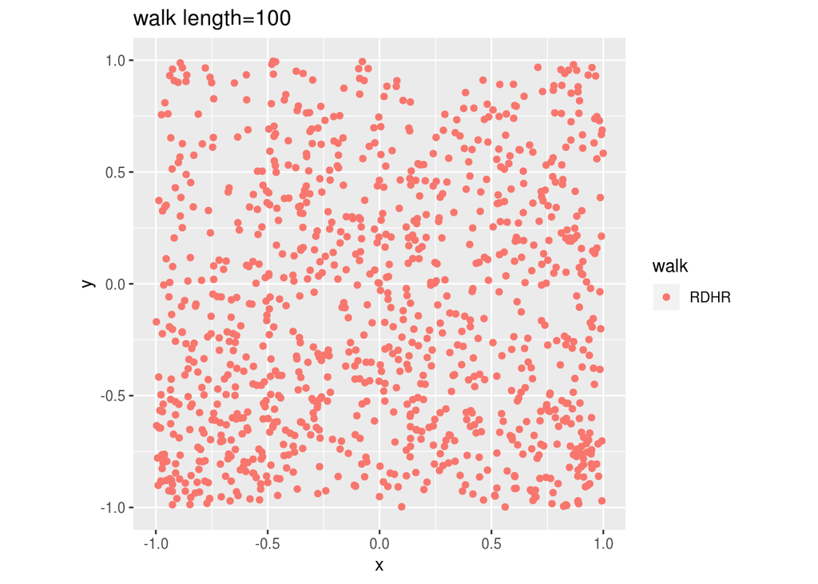

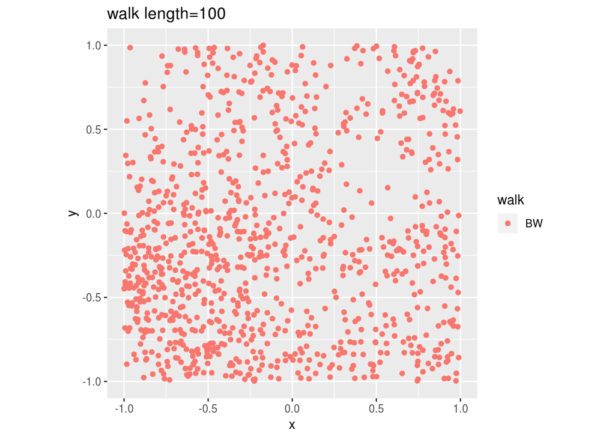

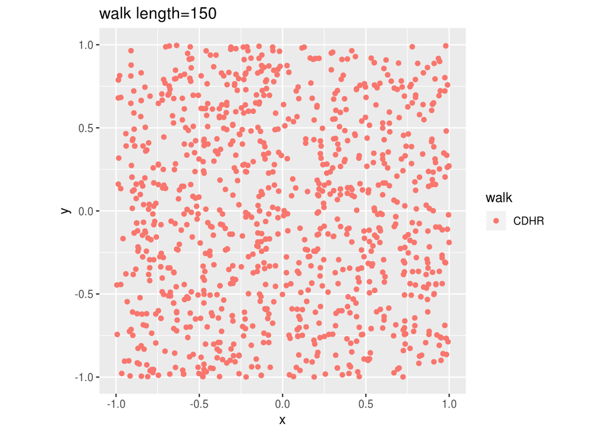

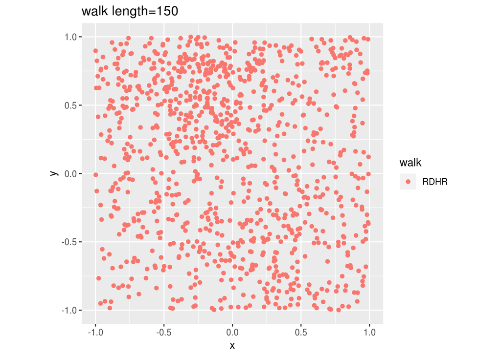

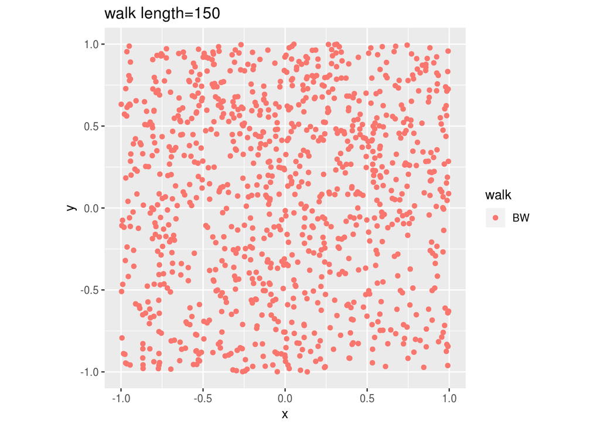

```r
library(ggplot2)
library(volesti)
for (step in c(1,20,100,150)){
  for (walk in c("CDHR", "RDHR", "BW")){
    P <- GenCube(100, 'H')
    points1 <- sample_points(P, WalkType = walk, walk_step = step, N=1000)
    g<-plot(ggplot(data.frame( x=points1[1,], y=points1[2,] )) + geom_point( aes(x=x, y=y, color=walk)) + coord_fixed(xlim = c(-1,1), ylim = c(-1,1)) + ggtitle(sprintf("walk length=%s", step, walk)))
  }
}
```

# Volume estimation

Now let’s compute our first example. The volume of the 3-dimensional cube.

```r
library(geometry)

PV <- GenCube(3,'V')
str(PV)
```

```
## Reference class 'Rcpp_Vpolytope' [package "volesti"] with 3 fields
##  $ V        : num [1:8, 1:3] -1 1 -1 1 -1 1 -1 1 -1 -1 ...
##  $ dimension: num 3
##  $ type     : int 2
##  and 16 methods, of which 2 are  possibly relevant:
##    finalize, initialize
```

```r
#P = GenRandVpoly(3, 6, body = 'cube')
tim1 <- system.time({ geom_values = convhulln(PV$V, options = 'FA') })
tim2 <- system.time({ vol2 = volume(PV) })

cat(sprintf("exact vol = %f\napprx vol = %f\nrelative error = %f\n",
            geom_values$vol, vol2, abs(geom_values$vol-vol2)/geom_values$vol))
```

```
## exact vol = 8.000000
## apprx vol = 8.155693
## relative error = 0.019462
```

Now try a higher dimensional example. By setting the `error` parameter we can control the apporximation of the algorithm.

```r
PH = GenCube(10,'H')
volumes <- list()
for (i in 1:10) {
  volumes[[i]] <- volume(PH, error=1) # default parameters
}
options(digits=10)
summary(as.numeric(volumes))
```

```
##      Min.   1st Qu.    Median      Mean   3rd Qu.      Max.
##  939.6240  994.8487 1016.0677 1013.5201 1030.3643 1097.2937
```

```r
volumes <- list()
for (i in 1:10) {
  volumes[[i]] <- volume(PH, error=0.5)
}
summary(as.numeric(volumes))
```

```
##     Min.  1st Qu.   Median     Mean  3rd Qu.     Max.
## 1000.501 1023.681 1029.736 1031.474 1035.866 1077.173
```

```r
library(geometry)

P = GenRandVpoly(15, 30)
# this will return an error about memory allocation, i.e. the dimension is too high for qhull
#tim1 <- system.time({ geom_values = convhulln(P$V, options = 'FA') })

#warning: this also takes a lot of time in v1.0.3
print(volume(P))
```

```
## [1] 3.392776724e-10
```

## Volume of Birkhoff polytopes

We now continue with a more interesting example, the 10-th Birkhoff polytope. It is known from https://arxiv.org/pdf/math/0305332.pdf that its volume equals

$\text{vol}(\mathcal{B}_{10})\frac{727291284016786420977508457990121862548823260052557333386607889}{828160860106766855125676318796872729344622463533089422677980721388055739956270293750883504892820848640000000}$

obtained via massive parallel computation.

```r
library(volesti)
P <- fileToMatrix('data/birk10.ine')
exact <- 727291284016786420977508457990121862548823260052557333386607889/828160860106766855125676318796872729344622463533089422677980721388055739956270293750883504892820848640000000

# warning the following will take around half an hour
print(volume(P, Algo = 'CG'))
```

```
## [1] 7.099957351e-55
```

Compare our computed estimation with the “normalized” floating point version of $\text{vol}(\mathcal{B}_{10})$

```r
n <- 10
vol_B10 <- 727291284016786420977508457990121862548823260052557333386607889/828160860106766855125676318796872729344622463533089422677980721388055739956270293750883504892820848640000000
print(vol_B10/(n^(n-1)))
```

```
## [1] 8.782005031e-55
```

# Rounding

We generate skinny polytopes, in particular skinny cubes of the form $\{x=(x_1,\dots,x_d)\ |\ x_1\leq 100, x_1\geq-100,x_i\leq 1,x_i\geq-1,x_i\in \mathbb{R}, \text{ for } i=2,\dots,d\}$.

Our random walks perform poorly on those polytopes espacially as the dimension increases. Note that if we use the `CDHR` walk here is cheating since we take advanatage of the instance structure.

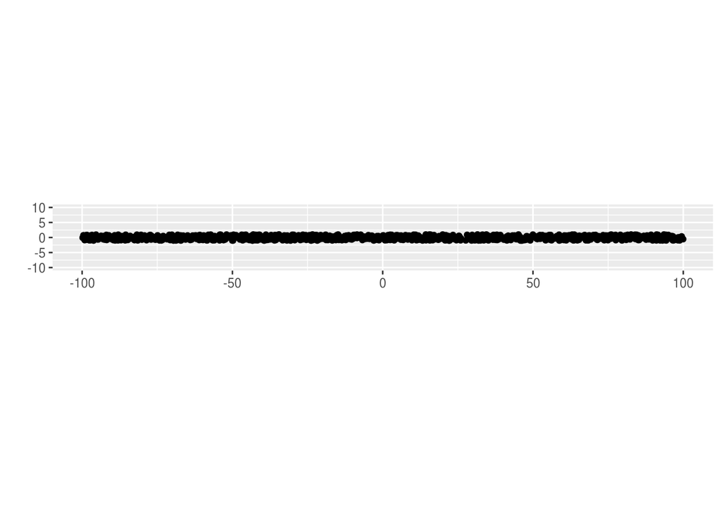

```r
library(ggplot2)

P = GenSkinnyCube(2)
points1 = sample_points(P, WalkType = "CDHR", N=1000)
ggplot(data.frame(x = c(points1[1,]), y = c(points1[2,])), aes(x=x, y=y)) + geom_point() +labs(x =" ", y = " ")+coord_fixed(ylim = c(-10,10))
```

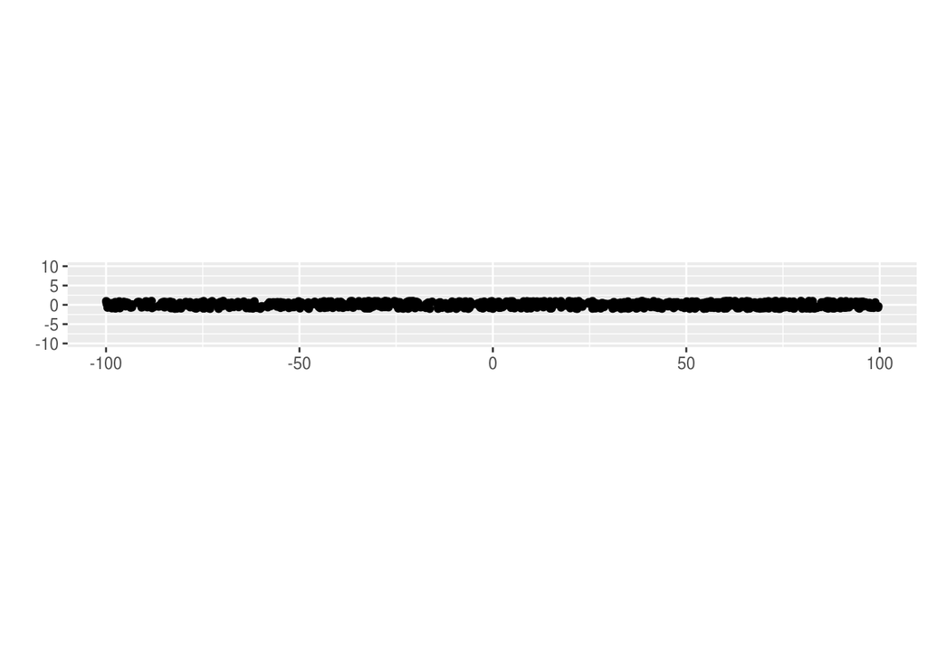

```r
points1 = sample_points(P, WalkType = "RDHR", N=1000)
ggplot(data.frame(x = c(points1[1,]), y = c(points1[2,])), aes(x=x, y=y)) + geom_point() +labs(x =" ", y = " ")+coord_fixed(ylim = c(-10,10))
```

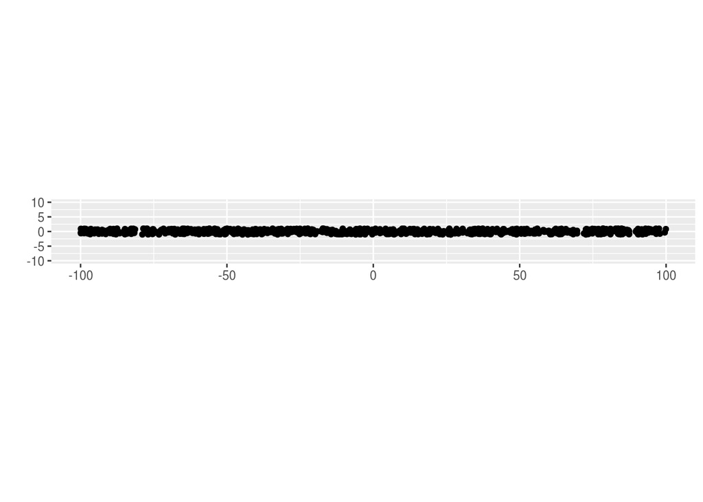

```r
P = GenSkinnyCube(10)
points1 = sample_points(P, WalkType = "CDHR", N=1000)
ggplot(data.frame(x = c(points1[1,]), y = c(points1[2,])), aes(x=x, y=y)) + geom_point() +labs(x =" ", y = " ")+coord_fixed(xlim = c(-100,100), ylim = c(-10,10))
```

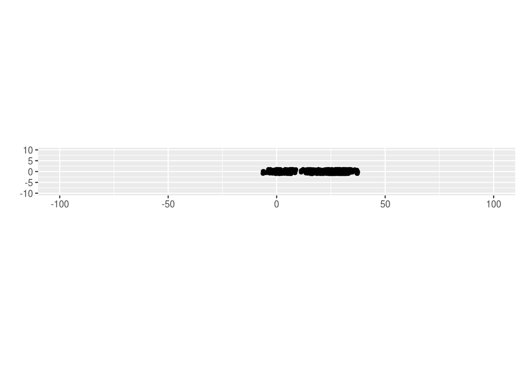

```r
points1 = sample_points(P, WalkType = "RDHR", N=1000)
ggplot(data.frame(x = c(points1[1,]), y = c(points1[2,])), aes(x=x, y=y)) + geom_point() +labs(x =" ", y = " ")+coord_fixed(xlim = c(-100,100), ylim = c(-10,10))
```

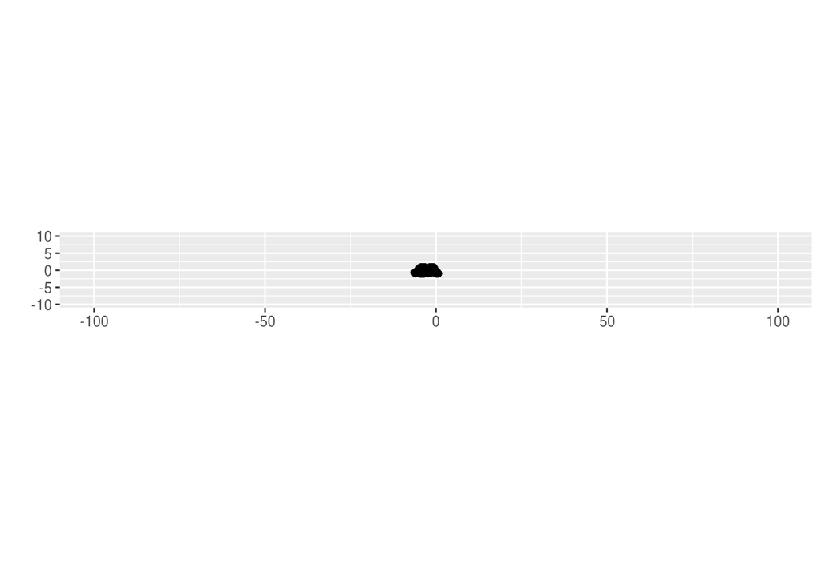

```r
P = GenSkinnyCube(100)
points1 = sample_points(P, WalkType = "RDHR", N=1000)
ggplot(data.frame(x = c(points1[1,]), y = c(points1[2,])), aes(x=x, y=y)) + geom_point() +labs(x =" ", y = " ")+coord_fixed(xlim = c(-100,100), ylim = c(-10,10))
```

Then we examine the problem of rounding by sampling in the original and then in the rounded polytope and look at the effect in volume computation.

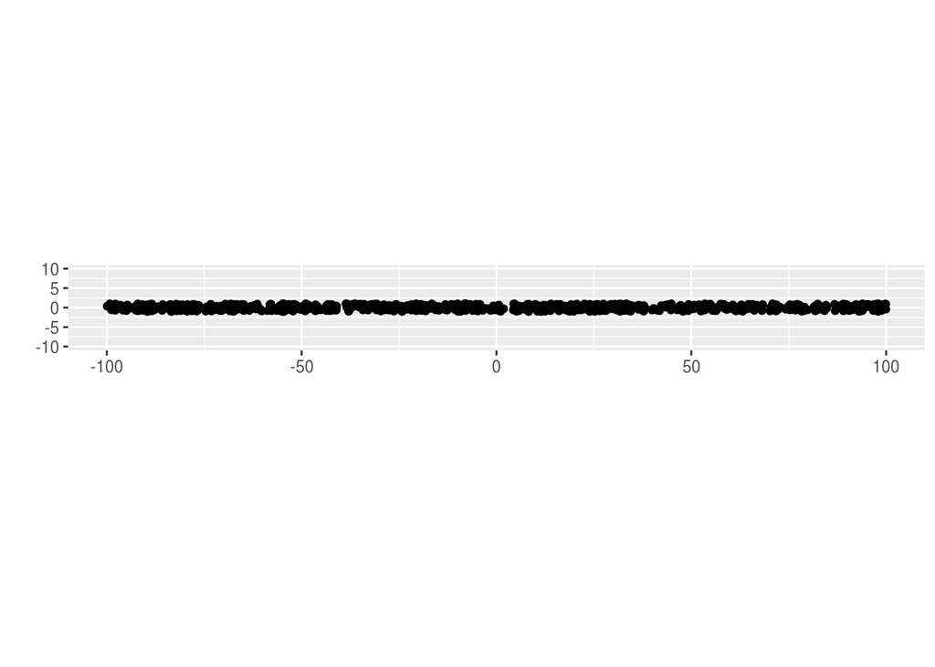

```r
library(ggplot2)

d <- 10

P = GenSkinnyCube(d)
points1 = sample_points(P, WalkType = "CDHR", N=1000)
ggplot(data.frame(x = c(points1[1,]), y = c(points1[2,])), aes(x=x, y=y)) + geom_point() +labs(x =" ", y = " ")+coord_fixed(ylim = c(-10,10))
```

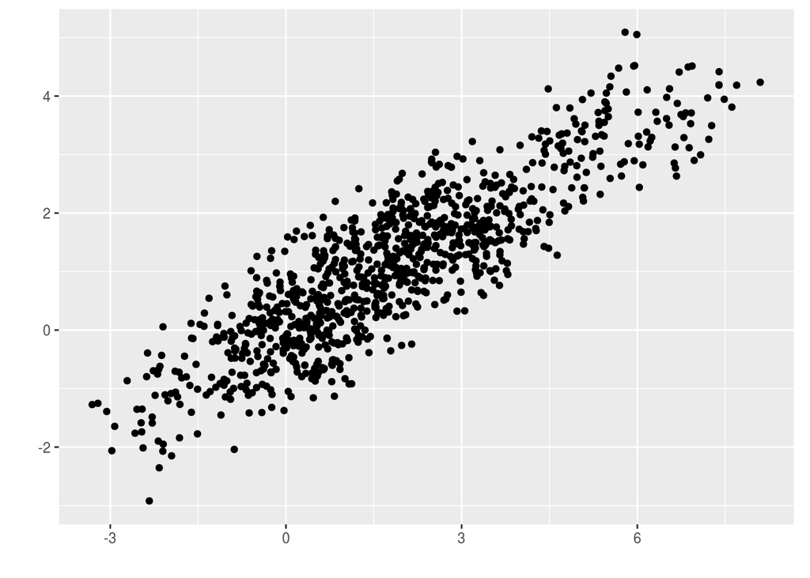

```r
P <- rand_rotate(P)$P

points1 = sample_points(P, WalkType = "RDHR", N=1000)
ggplot(data.frame(x = c(points1[1,]), y = c(points1[2,])), aes(x=x, y=y)) + geom_point() +labs(x =" ", y = " ")+coord_fixed()
```

```r
exact <- 2^d*100
cat("exact volume                 = ", exact , "\n")
```

```
## exact volume                 =  102400
```

```r
cat("volume estimation (no round) = ", volume(P, WalkType = "RDHR", rounding=FALSE), "\n")
```

```
## volume estimation (no round) =  33428.84862
```

```r
cat("volume estimation (rounding) = ", volume(P, WalkType = "RDHR", rounding=TRUE), "\n")
```

```
## volume estimation (rounding) =  81899.52397
```